# Patrones de puntos

Kenneth Roy Cabrera Torres

Miércoles, 2 de mayo de 2018.

## Lectura de la base de datos.

Distribución de la especie Hybanthus prunifolius (flor de lluvia) con un DAP mayor de 5 cm.

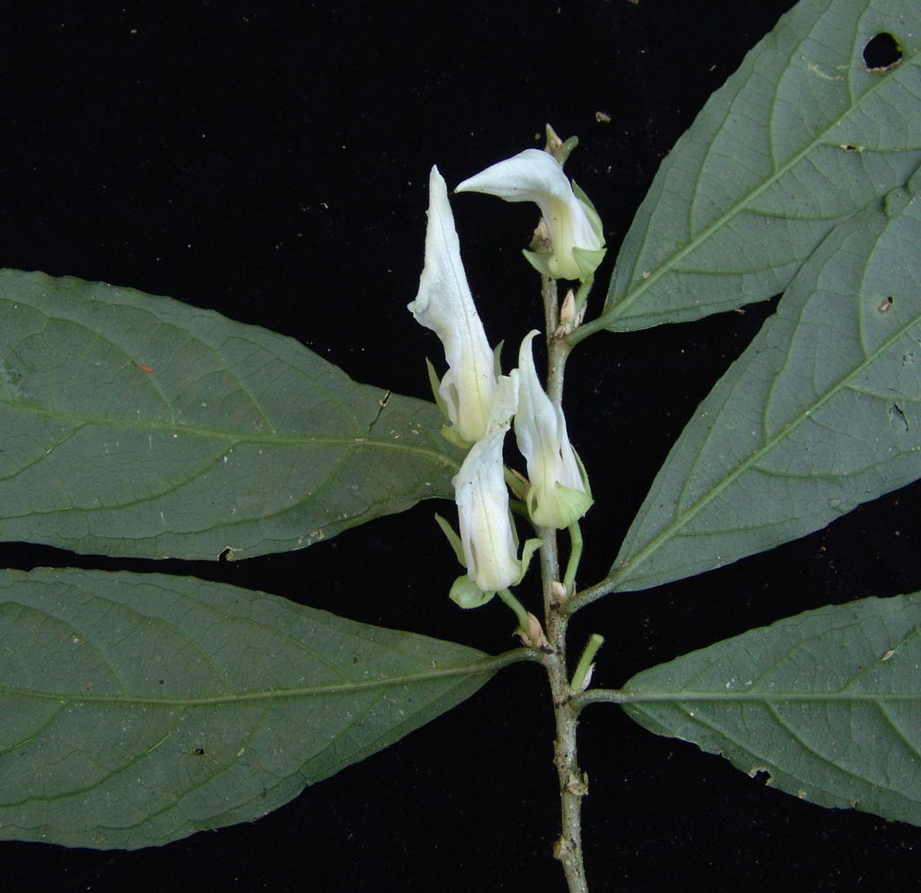

De acuerdo a la descripción hecha en [esta página](http://www.tropicos.org/name/33800563?projectid=7), se caracteríza por:

Arbustos o árboles, hasta 7 m de alto; ramas jóvenes pilosas, estriadas, gris claras. Hojas alternas, frecuentemente agrupadas en brotes cortos, elípticas, 4.5–15 cm de largo, atenuadas a acuminadas en el ápice, atenuadas en la base, irregularmente serradas o serruladas, lisas, adaxialmente seríceas a lo largo del nervio principal, abaxialmente seríceas cuando jóvenes, tricomas persistentes en el base y a lo largo del nervio principal; pecíolos cortos, estípulas 3–5 mm de largo, con una quilla ósea y con márgenes cartáceos, seríceas a lo largo de la quilla, persistentes. Flores 1–2 en brotes cortos, blancas, pedicelos delgados, 10–20 mm de largo; sépalos lanceolados, 7–11 mm de largo, seríceos; pétalo más inferior 23–45 mm de largo. Cápsula 18–20 mm de largo; semillas 4–5 mm de diámetro.

```r
hp1 <- read.csv2("Hp.csv", enc="latin1")
hp1$x <- hp1$x / 100
hp1$y <- hp1$y / 100
```

## Uso del paquete **spatstat**

```r
library(spatstat)
## Convertir a un objeto de patrones de puntos
pdp1 <- ppp(hp1$x, hp1$y, c(0, 10), c(0, 5), unitname=c("hectometro", "hectometros"))
```

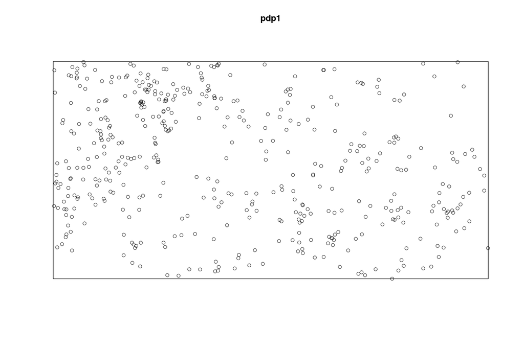

```r
## Gráfica del objeto de patrones de puntos.
plot(pdp1)
```

```r
## Resumen del objeto de patrones de puntos.
summary(pdp1)
```

```
## Planar point pattern:  450 points
## Average intensity 9 points per square hectometro
##
## Coordinates are given to 3 decimal places
## i.e. rounded to the nearest multiple of 0.001 hectometros
##
## Window: rectangle = [0, 10] x [0, 5] hectometros
## Window area = 50 square hectometros
## Unit of length: 1 hectometro
```

## Cálculo de la densidad mediante cuadrantes.

Prueba de hipóteis para saber si los puntos se distribuyen al azar o tienen algún patrón.

```r
CC1 <- quadratcount(pdp1, nx=10, ny=5)
CC1
```

```
##        x
## y       [0,1) [1,2) [2,3) [3,4) [4,5) [5,6) [6,7) [7,8) [8,9) [9,10]
##   [4,5]    16    16    32    23     4     6     6     7     3      2
##   [3,4)     8    18    21     3     9     8     3     8     1      1
##   [2,3)    18    19     7     5     2     7     9     8     4     10
##   [1,2)    19     9     4     7     9    15     5    14     8     12
##   [0,1)     4     7     6     7     6     7    11     6     9      1
```

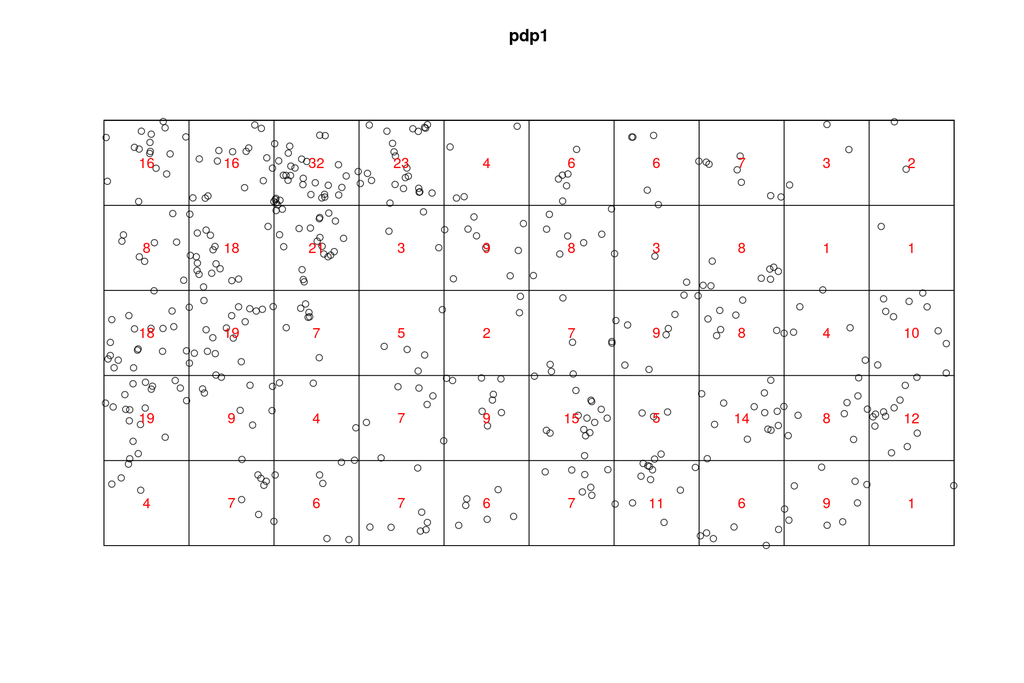

```r
plot(pdp1, pch=1)
plot(CC1, add=TRUE, col="red")
```

```r
quadrat.test(pdp1, nx=10, ny=5)
```

```
##
##  Chi-squared test of CSR using quadrat counts
##  Pearson X2 statistic
##
## data:  pdp1
## X2 = 223.56, df = 49, p-value < 2.2e-16
## alternative hypothesis: two.sided
##
## Quadrats: 10 by 5 grid of tiles
```

```r
quadrat.test(pdp1, alternative="regular", nx=10, ny=5)
```

```
##
##  Chi-squared test of CSR using quadrat counts
##  Pearson X2 statistic
##
## data:  pdp1
## X2 = 223.56, df = 49, p-value = 1
## alternative hypothesis: regular
##
## Quadrats: 10 by 5 grid of tiles
```

```r
quadrat.test(pdp1, alternative="clustered", nx=10, ny=5)
```

```
##
##  Chi-squared test of CSR using quadrat counts
##  Pearson X2 statistic
##
## data:  pdp1
## X2 = 223.56, df = 49, p-value < 2.2e-16
## alternative hypothesis: clustered
##
## Quadrats: 10 by 5 grid of tiles
```

## Gráfica de la estimación usando el K de Ripley.

$$K(r) = \lambda^{-1}\sum_{i \neq j} \frac{I(d_{ij} < r)}{n}$$

Dónde $\lambda$ es la densidad (número de unidades por área) de los eventos. $d_{ij}$ es la distancia euclídea entre el punto $i$ y el punto $j$.

Generalmente se estima como $\frac{n}{A}$, donde $A$ es el área de la región que contiene los $n$ puntos e $I()$ es la función indicadora (1 si el operando es verdadero, 0 en otro caso),

Para un proceso poisson homogéneo que también se conoce como un CSR (Complete Spatial Randomness) la función $K(r)$ se define como:

$$K(r) = \pi r^2$$

Otra manera de ver el estadístico es que $K(r)\lambda$ es igual al número de puntos esperado en el área a una distancia $r$ dada.

Se utiliza también la varianza estabilizada de la función $K(r)$ de Ripley denominada la función $L$.

Esta $L$ se define como:

$$\hat{L}(r) = \left( \frac{\hat{K}(r)}{\pi} \right)^\frac{1}{2}$$

```r
KR1  <-  Kest(pdp1)
KR1
```

```
## Function value object (class 'fv')
## for the function r -> K(r)
## ..............................................................
##        Math.label       Description
## r      r                distance argument r
## theo   K[pois](r)       theoretical Poisson K(r)
## border hat(K)[bord](r)  border-corrected estimate of K(r)
## trans  hat(K)[trans](r) translation-corrected estimate of K(r)
## iso    hat(K)[iso](r)   isotropic-corrected estimate of K(r)
## ..............................................................
## Default plot formula:  .~r
## where "." stands for 'iso', 'trans', 'border', 'theo'
## Recommended range of argument r: [0, 1.25]
## Available range of argument r: [0, 1.25]
## Unit of length: 1 hectometro
```

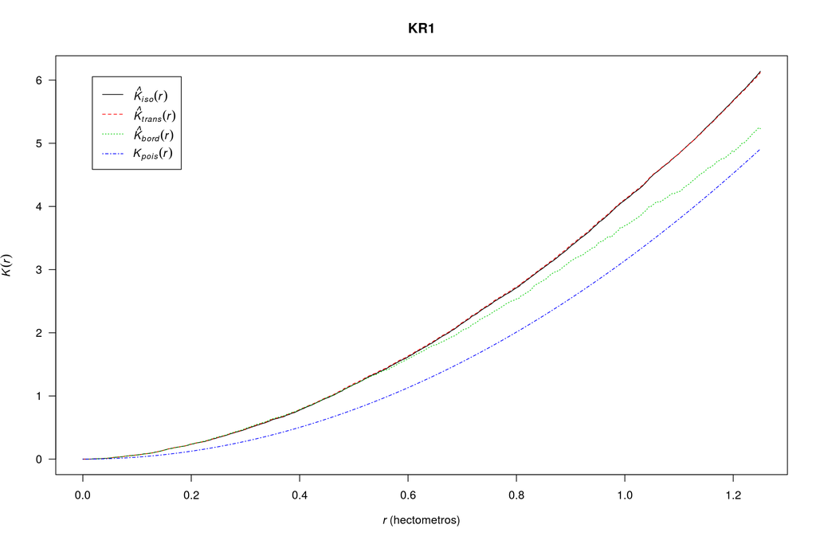

```r
plot(KR1,  las = 1)
```

## Estimación de estructura espacial de patrones de puntos.

```
## Generating 99 simulations of CSR  ...
## 1, 2, 3, 4, 5, 6, 7, 8, 9, 10, 11, 12, 13, 14, 15, 16, 17, 18, 19, 20, 21, 22, 23, 24, 25, 26, 27, 28, 29, 30, 31, 32, 33, 34, 35, 36, 37, 38, 39, 40, 41, 42, 43, 44, 45, 46, 47, 48, 49, 50,
## 51, 52, 53, 54, 55, 56, 57, 58, 59, 60, 61, 62, 63, 64, 65, 66, 67, 68, 69, 70, 71, 72, 73, 74, 75, 76, 77, 78, 79, 80, 81, 82, 83, 84, 85, 86, 87, 88, 89, 90, 91, 92, 93, 94, 95, 96, 97, 98,  99.
##
## Done.
```

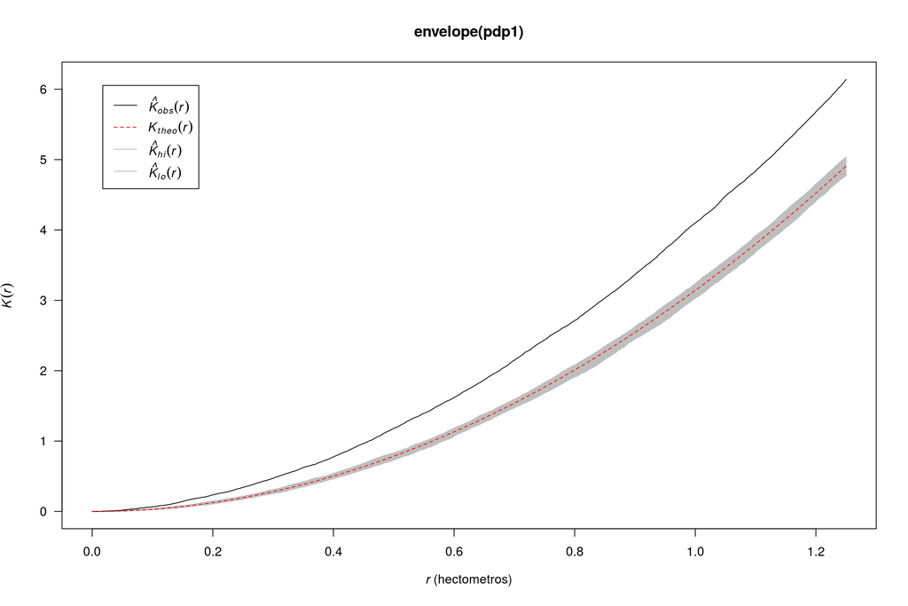

```r
plot(envelope(pdp1),  las = 1)
```

```
## Generating 99 simulations of CSR  ...
## 1, 2, 3, 4, 5, 6, 7, 8, 9, 10, 11, 12, 13, 14, 15, 16, 17, 18, 19, 20, 21, 22, 23, 24, 25, 26, 27, 28, 29, 30, 31, 32, 33, 34, 35, 36, 37, 38, 39, 40, 41, 42, 43, 44, 45, 46, 47, 48, 49, 50,
## 51, 52, 53, 54, 55, 56, 57, 58, 59, 60, 61, 62, 63, 64, 65, 66, 67, 68, 69, 70, 71, 72, 73, 74, 75, 76, 77, 78, 79, 80, 81, 82, 83, 84, 85, 86, 87, 88, 89, 90, 91, 92, 93, 94, 95, 96, 97, 98,  99.
##
## Done.
```

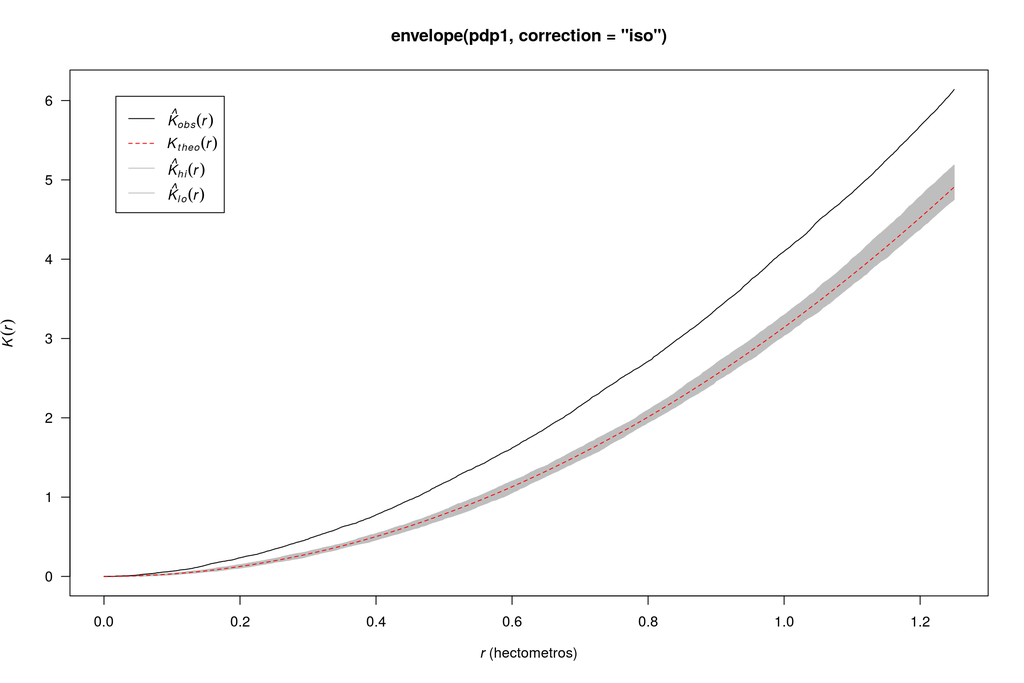

```r
plot(envelope(pdp1, correction = "iso"),  las = 1)
```

## Estimación de la densidad de patrones de puntos.

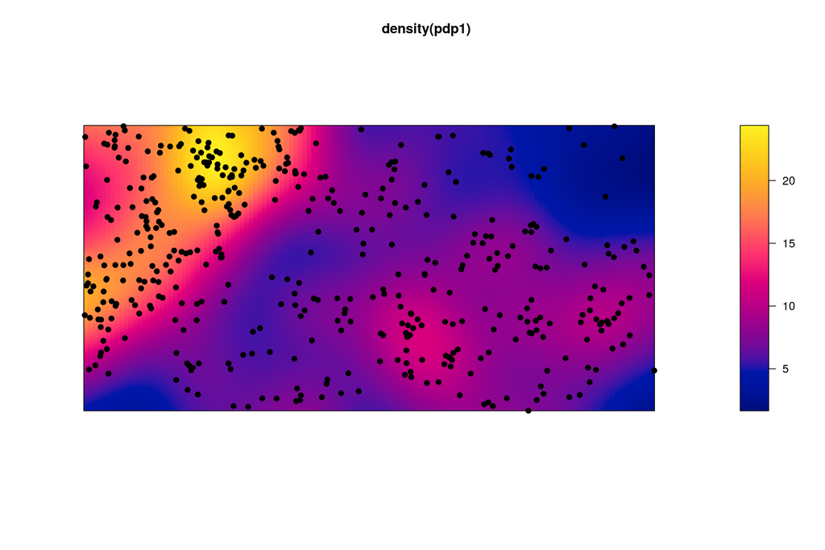

```r
plot(density(pdp1), las = 1)
points(pdp1, pch = 19)
```

## Modelación de patrones de puntos

```r
m0 <- ppm(pdp1, ~1)
m0
```

```
## Stationary Poisson process
## Intensity: 9
##             Estimate       S.E.  CI95.lo  CI95.hi Ztest     Zval
## log(lambda) 2.197225 0.04714045 2.104831 2.289618   *** 46.61017
```

```r
summary(m0)
```

```
## Point process model
## Fitting method: maximum likelihood
## Model was fitted analytically
## Call:
## ppm.ppp(Q = pdp1, trend = ~1)
## Edge correction: "border"
##  [border correction distance r = 0 ]
## ----------------------------------------------------------------------------------------------------
## Quadrature scheme = data + dummy + weights
##
## Data pattern:
## Planar point pattern:  450 points
## Average intensity 9 points per square hectometro
## Window: rectangle = [0, 10] x [0, 5] hectometros
## Window area = 50 square hectometros
## Unit of length: 1 hectometro
##
## Dummy quadrature points:
##      50 x 50 grid of dummy points, plus 4 corner points
##      dummy spacing: 0.2 x 0.1 hectometros
##
## Original dummy parameters: =
## Planar point pattern:  2504 points
## Average intensity 50.1 points per square hectometro
## Window: rectangle = [0, 10] x [0, 5] hectometros
## Window area = 50 square hectometros
## Unit of length: 1 hectometro
## Quadrature weights:
##      (counting weights based on 50 x 50 array of rectangular tiles)
## All weights:
##  range: [0.00333, 0.02]  total: 50
## Weights on data points:
##  range: [0.00333, 0.01]  total: 4.06
## Weights on dummy points:
##  range: [0.00333, 0.02]  total: 45.9
## ----------------------------------------------------------------------------------------------------
## FITTED MODEL:
##
## Stationary Poisson process
##
## ---- Intensity: ----
##
##
## Uniform intensity:
## [1] 9
##
##             Estimate       S.E.  CI95.lo  CI95.hi Ztest     Zval
## log(lambda) 2.197225 0.04714045 2.104831 2.289618   *** 46.61017
##
## ----------- gory details -----
##
## Fitted regular parameters (theta):
## log(lambda)
##    2.197225
##
## Fitted exp(theta):
## log(lambda)
##           9
```

```
## Generating 99 simulations of CSR  ...
## 1, 2, 3, 4, 5, 6, 7, 8, 9, 10, 11, 12, 13, 14, 15, 16, 17, 18, 19, 20, 21, 22, 23, 24, 25, 26, 27, 28, 29, 30, 31, 32, 33, 34, 35, 36, 37, 38, 39, 40, 41, 42, 43, 44, 45, 46, 47, 48, 49, 50,
## 51, 52, 53, 54, 55, 56, 57, 58, 59, 60, 61, 62, 63, 64, 65, 66, 67, 68, 69, 70, 71, 72, 73, 74, 75, 76, 77, 78, 79, 80, 81, 82, 83, 84, 85, 86, 87, 88, 89, 90, 91, 92, 93, 94, 95, 96, 97, 98,  99.
##
## Done.
```

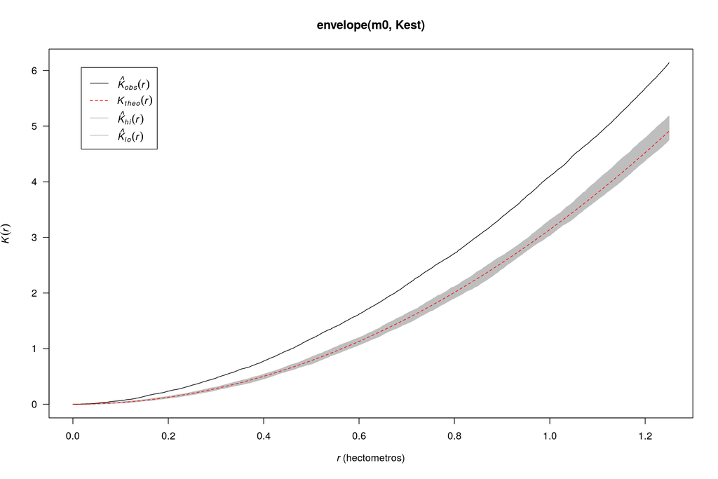

```r
plot(envelope(m0, Kest),  las = 1)
```

```r
m1 <- ppm(pdp1, ~ x + y + x:y, Poisson())
m1
```

```
## Nonstationary Poisson process
##
## Log intensity:  ~x + y + x:y
##
## Fitted trend coefficients:
## (Intercept)           x           y         x:y
##  1.76516378  0.04992622  0.34810073 -0.06187302
##
##                Estimate       S.E.     CI95.lo     CI95.hi Ztest      Zval
## (Intercept)  1.76516378 0.19145137  1.38992599  2.14040156   ***  9.219907
## x            0.04992622 0.03432829 -0.01735599  0.11720842        1.454375
## y            0.34810073 0.05874170  0.23296911  0.46323236   ***  5.925956
## x:y         -0.06187302 0.01161869 -0.08464524 -0.03910081   *** -5.325301
```

```r
summary(m1)
```

```
## Point process model
## Fitting method: maximum likelihood (Berman-Turner approximation)
## Model was fitted using glm()
## Algorithm converged
## Call:
## ppm.ppp(Q = pdp1, trend = ~x + y + x:y, interaction = Poisson())
## Edge correction: "border"
##  [border correction distance r = 0 ]
## ----------------------------------------------------------------------------------------------------
## Quadrature scheme = data + dummy + weights
##
## Data pattern:
## Planar point pattern:  450 points
## Average intensity 9 points per square hectometro
## Window: rectangle = [0, 10] x [0, 5] hectometros
## Window area = 50 square hectometros
## Unit of length: 1 hectometro
##
## Dummy quadrature points:
##      50 x 50 grid of dummy points, plus 4 corner points
##      dummy spacing: 0.2 x 0.1 hectometros
##
## Original dummy parameters: =
## Planar point pattern:  2504 points
## Average intensity 50.1 points per square hectometro
## Window: rectangle = [0, 10] x [0, 5] hectometros
## Window area = 50 square hectometros
## Unit of length: 1 hectometro
## Quadrature weights:
##      (counting weights based on 50 x 50 array of rectangular tiles)
## All weights:
##  range: [0.00333, 0.02]  total: 50
## Weights on data points:
##  range: [0.00333, 0.01]  total: 4.06
## Weights on dummy points:
##  range: [0.00333, 0.02]  total: 45.9
## ----------------------------------------------------------------------------------------------------
## FITTED MODEL:
##
## Nonstationary Poisson process
```

[output cut: 9 more lines]

```
##                Estimate       S.E.     CI95.lo     CI95.hi Ztest      Zval
## (Intercept)  1.76516378 0.19145137  1.38992599  2.14040156   ***  9.219907
## x            0.04992622 0.03432829 -0.01735599  0.11720842        1.454375
## y            0.34810073 0.05874170  0.23296911  0.46323236   ***  5.925956
## x:y         -0.06187302 0.01161869 -0.08464524 -0.03910081   *** -5.325301
##
## ----------- gory details -----
##
## Fitted regular parameters (theta):
## (Intercept)           x           y         x:y
##  1.76516378  0.04992622  0.34810073 -0.06187302
##
## Fitted exp(theta):
## (Intercept)           x           y         x:y
##   5.8425292   1.0511935   1.4163749   0.9400022
```

```
## Generating 99 simulated realisations of fitted Poisson model  ...
## 1, 2, 3, 4, 5, 6, 7, 8, 9, 10, 11, 12, 13, 14, 15, 16, 17, 18, 19, 20, 21, 22, 23, 24, 25, 26, 27, 28, 29, 30, 31, 32, 33, 34, 35, 36, 37, 38, 39, 40, 41, 42, 43, 44, 45, 46, 47, 48, 49, 50,
## 51, 52, 53, 54, 55, 56, 57, 58, 59, 60, 61, 62, 63, 64, 65, 66, 67, 68, 69, 70, 71, 72, 73, 74, 75, 76, 77, 78, 79, 80, 81, 82, 83, 84, 85, 86, 87, 88, 89, 90, 91, 92, 93, 94, 95, 96, 97, 98,  99.
##
## Done.
```

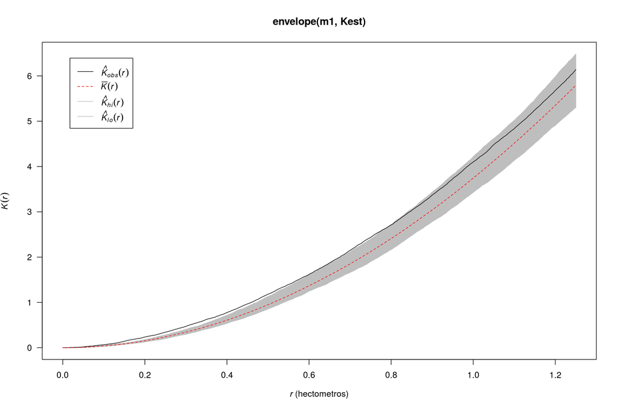

```r
plot(envelope(m1, Kest),  las = 1)
```

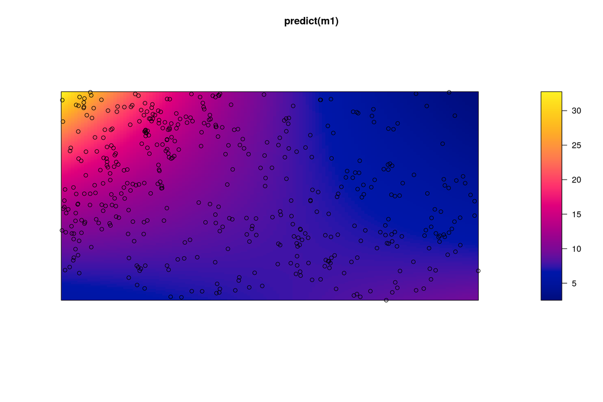

```r
plot(predict(m1), las = 1)
points(pdp1)
```

```r
m2 <- kppm(pdp1 ~ x + y + x:y)
m2
```

```
## Inhomogeneous cluster point process model
## Fitted to point pattern dataset 'pdp1'
## Fitted by minimum contrast
##  Summary statistic: inhomogeneous K-function
##
## Log intensity:  ~x + y + x:y
##
## Fitted trend coefficients:
## (Intercept)           x           y         x:y
##  1.76516378  0.04992622  0.34810073 -0.06187302
##
## Cluster model: Thomas process
## Fitted cluster parameters:
##     kappa     scale
## 5.7526372 0.1344336
## Mean cluster size:  [pixel image]
```

```r
summary(m2)
```

```
## Inhomogeneous cluster point process model
## Fitted to point pattern dataset 'pdp1'
## Fitted by minimum contrast
##  Summary statistic: inhomogeneous K-function
##
## ----------- TREND MODEL -----
## Point process model
## Fitting method: maximum likelihood (Berman-Turner approximation)
## Model was fitted using glm()
## Algorithm converged
## Call:
## ppm.ppp(Q = X, trend = trend, rename.intercept = FALSE, covariates = covariates,
##     covfunargs = covfunargs, use.gam = use.gam, forcefit = TRUE,
##     nd = nd, eps = eps)
## Edge correction: "border"
##  [border correction distance r = 0 ]
## ----------------------------------------------------------------------------------------------------
## Quadrature scheme = data + dummy + weights
##
## Data pattern:
## Planar point pattern:  450 points
## Average intensity 9 points per square hectometro
## Window: rectangle = [0, 10] x [0, 5] hectometros
## Window area = 50 square hectometros
## Unit of length: 1 hectometro
##
## Dummy quadrature points:
##      50 x 50 grid of dummy points, plus 4 corner points
##      dummy spacing: 0.2 x 0.1 hectometros
##
## Original dummy parameters: =
## Planar point pattern:  2504 points
## Average intensity 50.1 points per square hectometro
## Window: rectangle = [0, 10] x [0, 5] hectometros
## Window area = 50 square hectometros
## Unit of length: 1 hectometro
## Quadrature weights:
##      (counting weights based on 50 x 50 array of rectangular tiles)
## All weights:
##  range: [0.00333, 0.02]  total: 50
```

[output cut: 33 more lines]

```
## ----------- CLUSTER MODEL -----------
## Model: Thomas process
##
## Fitted cluster parameters:
##     kappa     scale
## 5.7526372 0.1344336
## Mean cluster size:  [pixel image]
##
## Final standard error and CI
## (allowing for correlation of cluster process):
##                Estimate       S.E.     CI95.lo     CI95.hi Ztest      Zval
## (Intercept)  1.76516378 0.30308566  1.17112680  2.35920075   ***  5.823977
## x            0.04992622 0.05287046 -0.05369799  0.15355042        0.944312
## y            0.34810073 0.10124292  0.14966826  0.54653320   ***  3.438272
## x:y         -0.06187302 0.01860778 -0.09834360 -0.02540244   *** -3.325116
```

```
## Generating 99 simulated realisations of fitted cluster model  ...
## 1, 2, 3, 4, 5, 6, 7, 8, 9, 10, 11, 12, 13, 14, 15, 16, 17, 18, 19, 20, 21, 22, 23, 24, 25, 26, 27, 28, 29, 30, 31, 32, 33, 34, 35, 36, 37, 38, 39, 40, 41, 42, 43, 44, 45, 46, 47, 48, 49, 50,
## 51, 52, 53, 54, 55, 56, 57, 58, 59, 60, 61, 62, 63, 64, 65, 66, 67, 68, 69, 70, 71, 72, 73, 74, 75, 76, 77, 78, 79, 80, 81, 82, 83, 84, 85, 86, 87, 88, 89, 90, 91, 92, 93, 94, 95, 96, 97, 98,  99.
##
## Done.
```

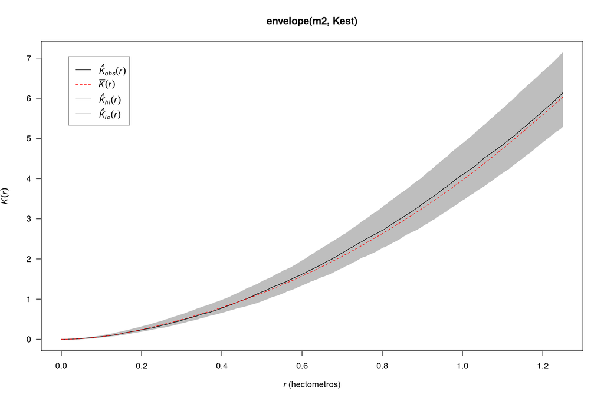

```r
plot(envelope(m2, Kest),  las = 1)
```

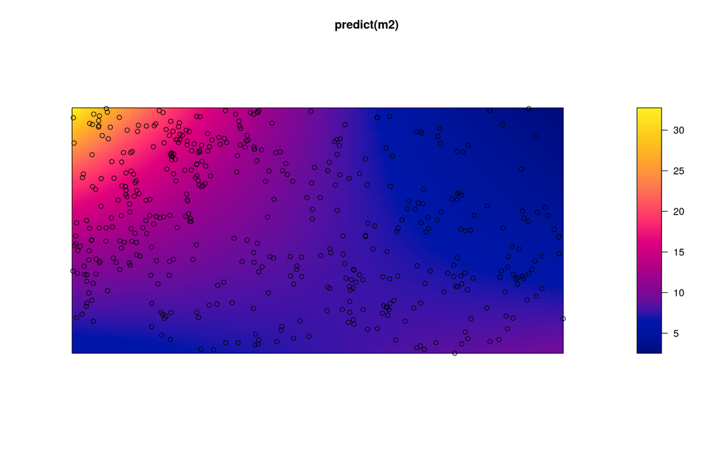

```r
plot(predict(m2), las = 1)
points(pdp1)
```